# **REM analysis vignette**

## 3.3 Encounter rate

Finally, we will estimate the encounter rate. In our data frame (*dataREM*), a new row was added each time an individual entered the detection zone (i.e., each encounter), with individuals treated as the unit of observation. Based on this, we will aggregate the number of rows for each (dataREM$camera). In addition, the sampling effort for each camera trap will be estimated using the information provided in (*operat*), which records the operational period of each camera.

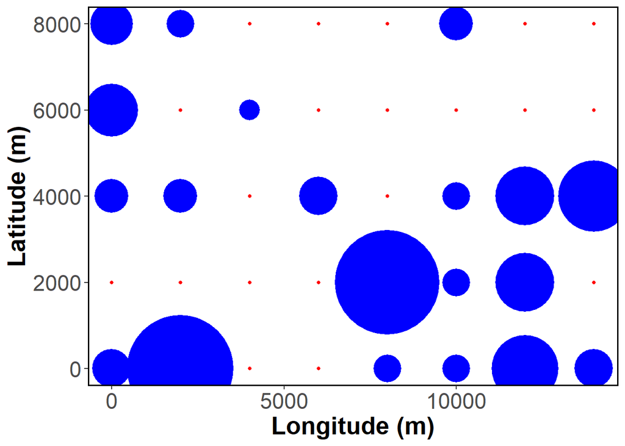

**Figure 6**: Encounter rate map. The areas of the blue circles are proportional to the encounter rates

In summary, we need a data frame (here *enc_rate*) in which one column represent the *y* parameter (here *Freq*) and another column represent *t* parameter (here *days*) of the REM equation.

```r
head(enc_rate) # data frame to estimate encounter rate
```

```
##   Freq days
## 1    4   60
## 2   34   60
## 3    0   40
## 4    0   60
## 5    2   60
## 6    2   60
```

As **Fig. 6** shows, encounter rates are highly aggregated. In 20 of the 40 cameras, no animals were detected, whereas in two cameras more than 30 sequences were recorded at each site. This pattern is common in REM studies due to the random placement of cameras and the naturally uneven distribution of animals. Crucially, most of the variance in density estimates arises from the variation in encounter rates among camera traps.

# 4. Density results

After estimate all the parameters necessary to apply REM, we can estimate population density.

```r
# We include in a list average values of day range and detection zone
param <- list(DR = DR,
              r = EfecRad$EDR / 1000,
              theta = EfecAng_mean*2)

# We include in a list standard error values of day range and detection zone
paramse <- list(DR = DR_se,
                r = EfecRad$se.EDR / 1000,
                theta = EfecAng_SE*2)

# Density estimation
density<-bootTRD(enc_rate$Freq, enc_rate$days, param, paramse); density
```

```
##       Density       SE
## [1,] 3.347081 1.103533
```

```r
# CV
density[,2]/density[,1]
```

```
##        SE
## 0.3297001
```

```r
# Log-normal CIs
df_lnorm_confint <- lnorm_confint(density[,1], density[,2])
```

```r
# Saving results
head(results)
```

```
##       seq   tm dr(km/day) dr_se(km/day)     r(m)   r_se(m) ang(rad) ang_se(rad)
## Value 160 2218   4.185252     0.5580187 5.736822 0.2601836     0.82  0.08185672
##       d(ind/km2) d_se(ind/km2) lcl_lognorm95% ucl_lognorm95%
## Value   3.347081      1.103533       1.783335       6.282023
```